# Mock Technical Interview

Joshua Susanto 405568250

6/8/2021

```r
load("_stats20_S2021_final__405568250.RData")
load("Economics.RData")
load("Demographic.RData")
load("Education.RData")
load("Language.RData")
library(ggplot2)
```

## 1(A)

```r
dim(Demographic)
```

```
## [1] 33120    22
```

```r
dim(Education)
```

```
## [1] 33120    18
```

```r
zipcode <- merge(x = Demographic, y = Education, by = "zipcode")
dim(zipcode)
```

```
## [1] 33120    39
```

```r
dim(Economics)
```

```
## [1] 33120    13
```

```r
zipcode2 <- merge(x = zipcode, y = Economics, by = "zipcode")
dim(zipcode2)
```

```
## [1] 33120    51
```

```r
dim(Language)
```

```
## [1] 33120    39
```

```r
zipcode3 <- merge(x = zipcode2, y = Language, by = "zipcode")
str(xdf)
```

```
## 'data.frame':    22500 obs. of  56 variables:
##  $ STATENAME   : chr  "Alabama" "Alabama" "Alabama" "Alabama" ...
##  $ STATE       : num  1 1 1 1 1 1 1 1 1 1 ...
##  $ VE_TOTAL    : num  1 1 2 3 2 3 2 3 2 1 ...
##  $ zipcode     : chr  "36079" "35570" "35619" "35806" ...
##  $ REG_STAT    : num  1 1 1 1 1 1 1 1 1 1 ...
##  $ REG_STATNAME: chr  "Alabama" "Alabama" "Alabama" "Alabama" ...
##  $ OWNERNAME   : chr  "Driver (in this crash) was  Registered Owner" "Driver (in this crash) Not Registered Owner (Other Private Owner Listed)" "Vehicle Registered as Business/Company/Government Vehicle" "Driver (in this crash) Not Registered Owner (Other Private Owner Listed)" ...
##  $ DEFORMEDNAME: chr  "Disabling Damage" "Disabling Damage" "Disabling Damage" "Disabling Damage" ...
##  $ DR_ZIPNAME  : chr  "36081" "35581" "35674" "35763" ...
##  $ DR_HGT      : num  72 66 72 70 72 66 69 66 65 75 ...
##  $ DR_WGT      : num  225 125 300 200 195 210 213 125 170 170 ...
##  $ AGE         : num  58 34 61 62 46 54 42 37 34 40 ...
##  $ SEXNAME     : chr  "Male" "Female" "Male" "Male" ...
##  $ REST_USENAME: chr  "None Used" "Shoulder and Lap Belt Used" "Shoulder and Lap Belt Used" "Shoulder and Lap Belt Used" ...
```

[output cut: 42 more lines]

```r
dim(zipcode3)
```

```
## [1] 33120    89
```

```r
analysis.dataset <- merge(x = xdf, y = zipcode3, by = "zipcode")
str(analysis.dataset)
```

```
## 'data.frame':    22119 obs. of  144 variables:
##  $ zipcode                                                                                                                : chr  "01001" "01002" "01007" "01008" ...
##  $ STATENAME                                                                                                              : chr  "Massachusetts" "Massachusetts" "Massachusetts" "Massachusetts" ...
##  $ STATE                                                                                                                  : num  25 25 25 25 25 25 25 25 25 25 ...
##  $ VE_TOTAL                                                                                                               : num  2 1 2 1 2 2 3 2 1 2 ...
##  $ REG_STAT                                                                                                               : num  25 25 25 25 25 25 25 25 25 25 ...
##  $ REG_STATNAME                                                                                                           : chr  "Massachusetts" "Massachusetts" "Massachusetts" "Massachusetts" ...
##  $ OWNERNAME                                                                                                              : chr  "Driver (in this crash) was  Registered Owner" "Driver (in this crash) was  Registered Owner" "Driver (in this crash) was  Registered Owner" "Driver (in this crash) Not…
##  $ DEFORMEDNAME                                                                                                           : chr  "Disabling Damage" "Not Reported" "Disabling Damage" "Disabling Damage" ...
##  $ DR_ZIPNAME                                                                                                             : chr  "1001" "1002" "8344" "1001" ...
##  $ DR_HGT                                                                                                                 : num  62 70 65 59 75 67 68 72 70 999 ...
##  $ DR_WGT                                                                                                                 : num  999 202 999 999 999 999 999 999 999 166 ...
##  $ AGE                                                                                                                    : num  22 55 21 36 31 58 76 37 25 63 ...
##  $ SEXNAME                                                                                                                : chr  "Male" "Male" "Male" "Female" ...
##  $ REST_USENAME                                                                                                           : chr  "Shoulder and Lap Belt Used" "DOT-Compliant Motorcycle Helmet" "None Used / Not Applicable" "None Used" ...
```

[output cut: 86 more lines]

```r
dim(analysis.dataset)
```

```
## [1] 22119   144
```

## 1(B)

I defined dangerous as being involved in a fatal accident (whether or not the person died or not). Thus, I found the 10 most dangerous zipcodes for accidents involving any non-drivers by filtering out any accidents that didn’t involve more than just the driver. The 10 most dangerous zipcodes for drivers was defined as the zipcodes with the most amounts of accidents.

```r
summary(analysis.dataset$PERSONS)
```

```
##    Min. 1st Qu.  Median    Mean 3rd Qu.    Max.
##   1.000   2.000   2.000   3.134   4.000 120.000
```

```r
nondrivers <- analysis.dataset[analysis.dataset$PERSONS > 1,]
head(sort(tapply(X = nondrivers$zipcode, INDEX = nondrivers$zipcode, FUN = length), decreasing = TRUE), n = 10)
```

```
## 33578 79706 80401 93313 29073 85282 85635 95020 20772 32218
##    13    13    12    12    11    11    11    11    10    10
```

```r
head(sort(table(x = analysis.dataset$zipcode), decreasing = TRUE), n = 10)
```

```
## x
## 79706 80401 33578 93313 20772 29073 32256 78666 85282 32703
##    15    14    13    13    12    12    12    12    12    11
```

## 1(C)

Just from tabling the month and year values we can see that there isn’t much variation for total fatal accidents among years. There does, however, seem to be some sort of trend for months. Let’s dig a bit deeper on that.

```r
table(x = analysis.dataset$YEAR)
```

```
## x
## 2016 2017 2018 2019
## 5550 5659 5514 5396
```

```r
table(x = analysis.dataset$MONTH)
```

```
## x
##    1    2    3    4    5    6    7    8    9   10   11   12
## 1580 1405 1708 1776 1996 2106 2153 2042 1946 1946 1784 1677
```

Below we can see a visual of a timeline from 2016-2019 and the frequency of fatal crashes. We do perhaps observe an oscillating behavior that seems to occur annually, peaking around mid year (June-July according to our previous table).

```r
class(analysis.dataset$MONTH)
```

```
## [1] "numeric"
```

```r
class(analysis.dataset$YEAR)
```

```
## [1] "numeric"
```

```r
class(analysis.dataset$DAY)
```

```
## [1] "numeric"
```

```r
analysis.dataset$date <- paste(analysis.dataset$MONTH, analysis.dataset$YEAR, sep = "/")
analysis.dataset$date <- paste(analysis.dataset$DAY, analysis.dataset$date, sep = "/")
class(analysis.dataset$date)
```

```
## [1] "character"
```

```r
analysis.dataset$date <- as.Date(analysis.dataset$date, format = "%d/%m/%Y")
date <- sort(analysis.dataset$date)
date <- table(date)
date <- as.data.frame(date)
date$date <- as.Date(date$date, format = "%Y-%m-%d")
head(date)
```

```
##         date Freq
## 1 2016-01-01    9
## 2 2016-01-02   12
## 3 2016-01-03    9
## 4 2016-01-04   11
## 5 2016-01-05    6
## 6 2016-01-06   10
```

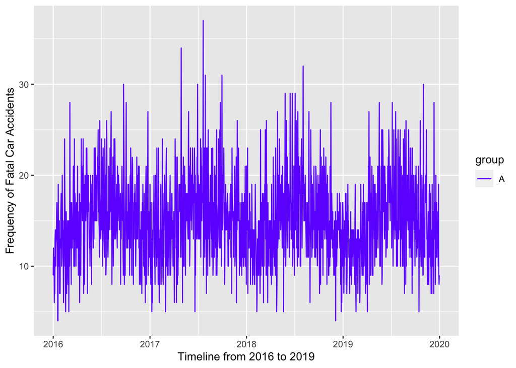

```r
date$group <- rep("A", times = length(date$date))
TL <- ggplot(data = date, aes(x = date, y = Freq, colour = group)) +
  geom_line(size = 0.5) +
  xlab("Timeline from 2016 to 2019") +
  ylab("Frequency of Fatal Car Accidents")
TL + scale_color_manual(values = c("#6f00ff"))
```

Let us try observing the data on a monthly trend.

```r
sortedM <- unique(sort(analysis.dataset$MONTH))
sortedY <- unique(sort(analysis.dataset$YEAR))
sortedM <- sort(rep(sortedM, times = 4))
sortedM
```

```
##  [1]  1  1  1  1  2  2  2  2  3  3  3  3  4  4  4  4  5  5  5  5  6  6  6  6  7
## [26]  7  7  7  8  8  8  8  9  9  9  9 10 10 10 10 11 11 11 11 12 12 12 12
```

```r
MYdates <- paste(rep(sortedY,times=12), sortedM, sep = "/")
MYdates <- paste(MYdates,1,sep = "/")
MYdates <- as.Date(MYdates, format = "%Y/%m/%d")
MYdates <- sort(MYdates)
MYdates
```

```
##  [1] "2016-01-01" "2016-02-01" "2016-03-01" "2016-04-01" "2016-05-01"
##  [6] "2016-06-01" "2016-07-01" "2016-08-01" "2016-09-01" "2016-10-01"
## [11] "2016-11-01" "2016-12-01" "2017-01-01" "2017-02-01" "2017-03-01"
## [16] "2017-04-01" "2017-05-01" "2017-06-01" "2017-07-01" "2017-08-01"
## [21] "2017-09-01" "2017-10-01" "2017-11-01" "2017-12-01" "2018-01-01"
## [26] "2018-02-01" "2018-03-01" "2018-04-01" "2018-05-01" "2018-06-01"
## [31] "2018-07-01" "2018-08-01" "2018-09-01" "2018-10-01" "2018-11-01"
## [36] "2018-12-01" "2019-01-01" "2019-02-01" "2019-03-01" "2019-04-01"
## [41] "2019-05-01" "2019-06-01" "2019-07-01" "2019-08-01" "2019-09-01"
## [46] "2019-10-01" "2019-11-01" "2019-12-01"
```

```r
class(analysis.dataset$MONTH)
```

```
## [1] "numeric"
```

```r
sixteen <- analysis.dataset[analysis.dataset$YEAR == 2016,]
seventeen <- analysis.dataset[analysis.dataset$YEAR == 2017,]
eighteen <- analysis.dataset[analysis.dataset$YEAR == 2018,]
nineteen  <- analysis.dataset[analysis.dataset$YEAR == 2019,]
sixteen <- table(sixteen$MONTH)
seventeen <- table(seventeen$MONTH)
eighteen <- table(eighteen$MONTH)
nineteen <- table(nineteen$MONTH)
month.by.year <- c(sixteen,seventeen,eighteen,nineteen)
month.by.year <- as.data.frame(month.by.year)
head(month.by.year)
```

```
##   month.by.year
## 1           363
## 2           361
## 3           458
## 4           446
## 5           504
## 6           522
```

```r
month.by.year$date <- MYdates
month.by.year$group <- rep("A", times = length(month.by.year$date))
```

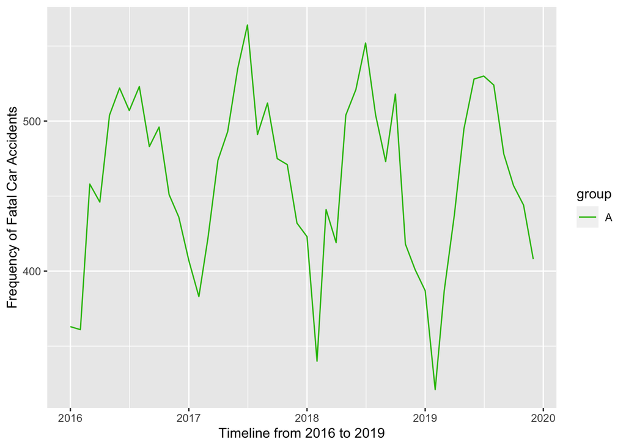

```r
mby <- ggplot(month.by.year, aes(x = date, y = month.by.year, color = group)) +
  geom_line() +
  xlab("Timeline from 2016 to 2019") +
  ylab("Frequency of Fatal Car Accidents")
mby + scale_color_manual(values = c("#29bd04"))
```